# **Impact of Severe Weather Events on Public Health and Economy in the United States**

*Haimo Liu, Aug.7th 2015*

## **Synopsis**

Storms and other severe weather events can cause both public health and economic problems for communities and municipalities. Many severe events can result in fatalities, injuries, and property damage, and preventing such outcomes to the extent possible is a key concern.

This project involves exploring the U.S. National Oceanic and Atmospheric Administration’s (NOAA) storm database. This database tracks characteristics of major storms and weather events in the United States, including when and where they occur, as well as estimates of any fatalities, injuries, and property damage. We will use the estimates of fatalities, injuries, property and crop damage to decide which types of event are most harmful to the population health and economy.

## **Basic Settings**

```r
library(reshape2)
library(plyr)
library(ggplot2)
require(gridExtra)
```

## **Data Processing**

### **1. Data Processing**

We first collect the storm data (skipped if data already exists). Please be patient and wait for a few moments:

```r
if ((!'stormData.csv.bz2' %in% dir(getwd()))) {
    download.file("http://d396qusza40orc.cloudfront.net/repdata%2Fdata%2FStormData.csv.bz2", destfile = "stormData.csv.bz2")
    }

if (!'stormData' %in% ls()) {
    stormData = read.csv("stormData.csv.bz2", sep = ",")
    }
```

Next, let’s take a quick look at the dataset and review the column information:

```r
dim(stormData)
```

```
## [1] 902297     37
```

```r
str(stormData)
```

```
## 'data.frame':    902297 obs. of  37 variables:
##  $ STATE__   : num  1 1 1 1 1 1 1 1 1 1 ...
##  $ BGN_DATE  : Factor w/ 16335 levels "1/1/1966 0:00:00",..: 6523 6523 4242 11116 2224 2224 2260 383 3980 3980 ...
##  $ BGN_TIME  : Factor w/ 3608 levels "00:00:00 AM",..: 272 287 2705 1683 2584 3186 242 1683 3186 3186 ...
##  $ TIME_ZONE : Factor w/ 22 levels "ADT","AKS","AST",..: 7 7 7 7 7 7 7 7 7 7 ...
##  $ COUNTY    : num  97 3 57 89 43 77 9 123 125 57 ...
##  $ COUNTYNAME: Factor w/ 29601 levels "","5NM E OF MACKINAC BRIDGE TO PRESQUE ISLE LT MI",..: 13513 1873 4598 10592 4372 10094 1973 23873 24418 4598 ...
##  $ STATE     : Factor w/ 72 levels "AK","AL","AM",..: 2 2 2 2 2 2 2 2 2 2 ...
##  $ EVTYPE    : Factor w/ 985 levels "   HIGH SURF ADVISORY",..: 834 834 834 834 834 834 834 834 834 834 ...
##  $ BGN_RANGE : num  0 0 0 0 0 0 0 0 0 0 ...
##  $ BGN_AZI   : Factor w/ 35 levels "","  N"," NW",..: 1 1 1 1 1 1 1 1 1 1 ...
##  $ BGN_LOCATI: Factor w/ 54429 levels "","- 1 N Albion",..: 1 1 1 1 1 1 1 1 1 1 ...
##  $ END_DATE  : Factor w/ 6663 levels "","1/1/1993 0:00:00",..: 1 1 1 1 1 1 1 1 1 1 ...
##  $ END_TIME  : Factor w/ 3647 levels ""," 0900CST",..: 1 1 1 1 1 1 1 1 1 1 ...
##  $ COUNTY_END: num  0 0 0 0 0 0 0 0 0 0 ...
```

[output cut: 23 more lines]

### **2. Data Preparation**

In the requirements, it says: “The events in the database start in the year 1950 and end in November 2011. In the earlier years of the database there are generally fewer events recorded, most likely due to a lack of good records. More recent years should be considered more complete.” Therefore, we want to take a subset of the original data which contains only good records.

First, let’s calculate (and plot) rowcount by years:

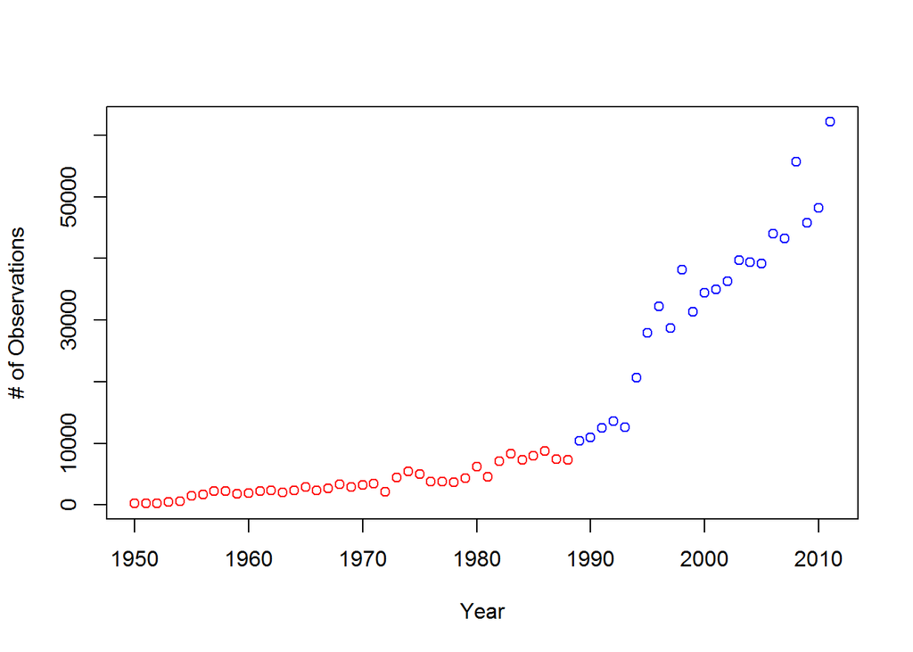

```r
stormData$year = as.numeric(format(as.POSIXct(as.character(stormData$BGN_DATE), format='%m/%d/%Y %H:%M:%S'), '%Y'))
rowcount_year = count(stormData$year)
plot(rowcount_year, col = ifelse (rowcount_year[, 2]<=10000, 'red', 'blue'), xlab = 'Year', ylab = '# of Observations')
```

Based on the above figure, we decided to take a subset of the dataset starting from year 1989 where we start to have more than 10,000 observations per year.

```r
stormsub = subset(stormData, stormData$year >= 1989)
dim(stormsub)
```

```
## [1] 762150     38
```

We ended up getting a dataset with **762150** observations and **38** features.

## **Data Analysis**

### **1. Events Hamful to Population Health**

First let’s take a look at columns that are relevant to public health, impute missing values if any:

```r
str(stormsub$INJURIES)
```

```
##  num [1:762150] 0 0 0 0 0 0 0 0 0 0 ...
```

```r
str(stormsub$FATALITIES)
```

```
##  num [1:762150] 0 0 0 0 0 0 0 0 0 0 ...
```

```r
sum(is.na(c(stormsub$INJURIES, stormsub$FATALITIES)))
```

```
## [1] 0
```

Next, let’s melt the dataset by event type, and find out which one(s) tend to have higher impact on public health:

```r
storm_melt = melt(stormsub, id.vars = 'EVTYPE', measure.vars = c('FATALITIES', 'INJURIES'))
head(storm_melt)
```

```
##      EVTYPE   variable value
## 1   TORNADO FATALITIES     0
## 2   TORNADO FATALITIES     0
## 3 TSTM WIND FATALITIES     0
## 4   TORNADO FATALITIES     0
## 5 TSTM WIND FATALITIES     0
## 6 TSTM WIND FATALITIES     0
```

```r
tail(storm_melt)
```

```
##                 EVTYPE variable value
## 1524295 WINTER WEATHER INJURIES     0
## 1524296      HIGH WIND INJURIES     0
## 1524297      HIGH WIND INJURIES     0
## 1524298      HIGH WIND INJURIES     0
## 1524299       BLIZZARD INJURIES     0
## 1524300     HEAVY SNOW INJURIES     0
```

```r
storm_cast = dcast(storm_melt, EVTYPE ~ variable, sum)
storm_fatal = storm_cast[, 1:2]
storm_injury = storm_cast[, c(1, 3)]
storm_top_fatal = storm_fatal[order(-storm_fatal$FATALITIES), ][1:10, ]
storm_top_injury = storm_injury[order(-storm_injury$INJURIES), ][1:10, ]
row.names(storm_top_fatal) = c(1:10)
row.names(storm_top_injury) = c(1:10)
storm_top_fatal$EVTYPE = factor(x = storm_top_fatal$EVTYPE, levels = storm_top_fatal$EVTYPE)
storm_top_injury$EVTYPE = factor(x = storm_top_injury$EVTYPE, levels = storm_top_injury$EVTYPE)
```

### **2. Events Hamful to Economy**

First, we try to convert PROPDMG and CROPDMG to readable numerics:

```r
storm_proc = stormsub
storm_proc$PROPDMGC = as.character(storm_proc$PROPDMGEXP)
tK = which(storm_proc$PROPDMGC == 'K')
tM = which(storm_proc$PROPDMGC == 'M')
tH = which(storm_proc$PROPDMGC == 'H')
tB = which(storm_proc$PROPDMGC == 'B')
tNA = which(storm_proc$PROPDMGC == '')
storm_proc$PROPDMGC[tK] = 10^3
storm_proc$PROPDMGC[tH] = 10^2
storm_proc$PROPDMGC[tB] = 10^9
storm_proc$PROPDMGC[tM] = 10^6
storm_proc$PROPDMGC[tNA] = 1
storm_proc$propDamage = as.numeric(storm_proc$PROPDMGC)*storm_proc$PROPDMG
storm_proc$CROPDMGC = as.character(storm_proc$CROPDMGEXP)
tK2 = which(storm_proc$CROPDMGC == 'K')
tM2 = which(storm_proc$CROPDMGC == 'M')
tH2 = which(storm_proc$CROPDMGC == 'H')
tB2 = which(storm_proc$CROPDMGC == 'B')
tNA2 = which(storm_proc$CROPDMGC == '')
storm_proc$CROPDMGC[tK2] = 10^3
storm_proc$CROPDMGC[tH2] = 10^2
storm_proc$CROPDMGC[tB2] = 10^9
storm_proc$CROPDMGC[tM2] = 10^6
storm_proc$CROPDMGC[tNA2] = 1
storm_proc$cropDamage = as.numeric(storm_proc$CROPDMGC)*storm_proc$CROPDMG
```

Next, let’s melt the dataset by event type, and find out which one(s) tend to have higher impact on economy:

```r
storm_melt2 = melt(storm_proc, id.vars = 'EVTYPE', measure.vars = c('propDamage', 'cropDamage'))
storm_cast2 = dcast(storm_melt2, EVTYPE ~ variable, sum)
storm_prop = storm_cast2[, 1:2]
storm_crop = storm_cast2[, c(1, 3)]
storm_top_prop = storm_prop[order(-storm_prop$propDamage), ][1:10, ]
storm_top_crop = storm_crop[order(-storm_crop$cropDamage), ][1:10, ]
storm_top_prop$EVTYPE = factor(x = storm_top_prop$EVTYPE, levels = storm_top_prop$EVTYPE)
storm_top_crop$EVTYPE = factor(x = storm_top_crop$EVTYPE, levels = storm_top_crop$EVTYPE)
```

## **Results**

### **1. Events Hamful to Population Health**

Please find below the two lists corresponding to the top 10 events hamful to fatalities and injuries respectively:

```r
storm_top_fatal
```

```
##            EVTYPE FATALITIES
## 1  EXCESSIVE HEAT       1903
## 2         TORNADO       1802
## 3     FLASH FLOOD        978
## 4            HEAT        937
## 5       LIGHTNING        816
## 6           FLOOD        470
## 7     RIP CURRENT        368
## 8       TSTM WIND        356
## 9       HIGH WIND        248
## 10      AVALANCHE        224
```

```r
storm_top_injury
```

```
##               EVTYPE INJURIES
## 1            TORNADO    27944
## 2              FLOOD     6789
## 3     EXCESSIVE HEAT     6525
## 4          TSTM WIND     5404
## 5          LIGHTNING     5230
## 6               HEAT     2100
## 7          ICE STORM     1975
## 8        FLASH FLOOD     1777
## 9  THUNDERSTORM WIND     1488
## 10      WINTER STORM     1321
```

To visualize the data more clearly:

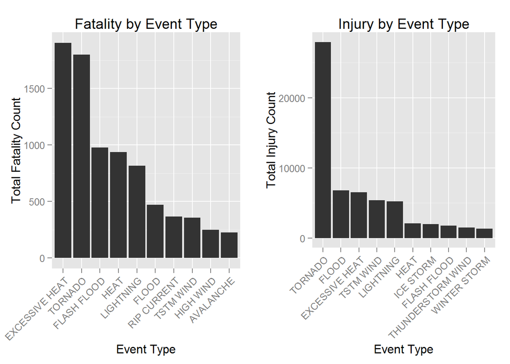

```r
p1 = qplot(EVTYPE, FATALITIES, data = storm_top_fatal, geom = 'bar', stat = 'identity') + xlab('Event Type') + ylab('Total Fatality Count') + theme(axis.text.x = element_text(angle = 45, hjust = 1)) + ggtitle('Fatality by Event Type')

p2 = qplot(EVTYPE, INJURIES, data = storm_top_injury, geom = 'bar', stat = 'identity') + xlab('Event Type') + ylab('Total Injury Count') + theme(axis.text.x = element_text(angle = 45, hjust = 1)) + ggtitle('Injury by Event Type')

grid.arrange(p1, p2, ncol = 2)
```

### **2. Events Hamful to Economy**

Please find below the two lists corresponding to the top 10 events hamful to properties and crops respectively:

```r
storm_top_prop
```

```
##                EVTYPE   propDamage
## 170             FLOOD 144657709807
## 411 HURRICANE/TYPHOON  69305840000
## 670       STORM SURGE  43323536000
## 402         HURRICANE  11868319010
## 848    TROPICAL STORM   7703890550
## 972      WINTER STORM   6688497250
## 590       RIVER FLOOD   5118945500
## 957          WILDFIRE   4765114000
## 671  STORM SURGE/TIDE   4641188000
## 856         TSTM WIND   4484928440
```

```r
storm_top_crop
```

```
##                EVTYPE  cropDamage
## 95            DROUGHT 13972566000
## 170             FLOOD  5661968450
## 590       RIVER FLOOD  5029459000
## 427         ICE STORM  5022113500
## 402         HURRICANE  2741910000
## 411 HURRICANE/TYPHOON  2607872800
## 153       FLASH FLOOD  1421317100
## 140      EXTREME COLD  1292973000
## 212      FROST/FREEZE  1094086000
## 290        HEAVY RAIN   733399800
```

To visualize the data more clearly:

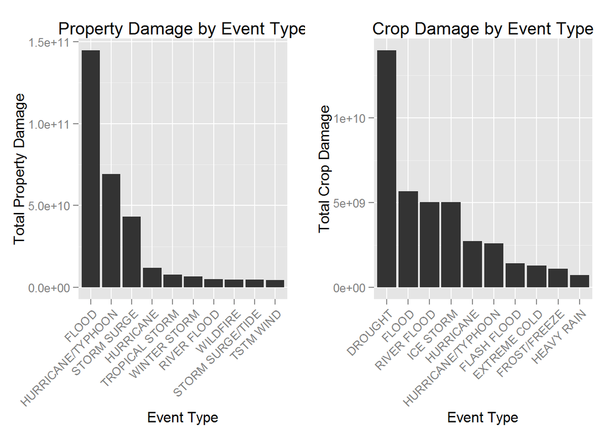

```r
p3 = qplot(EVTYPE, propDamage, data = storm_top_prop, geom = 'bar', stat = 'identity') + xlab('Event Type') + ylab('Total Property Damage') + theme(axis.text.x = element_text(angle = 45, hjust = 1)) + ggtitle('Property Damage by Event Type')

p4 = qplot(EVTYPE, cropDamage, data = storm_top_crop, geom = 'bar', stat = 'identity') + xlab('Event Type') + ylab('Total Crop Damage') + theme(axis.text.x = element_text(angle = 45, hjust = 1)) + ggtitle('Crop Damage by Event Type')

grid.arrange(p3, p4, ncol = 2)
```

**Across the United States, Flood and Drought are most harmful to economy, from the perspective of property damage and crop damage respectively**